# R Notebook

#### Standard heatmap (Euclidean Distances)

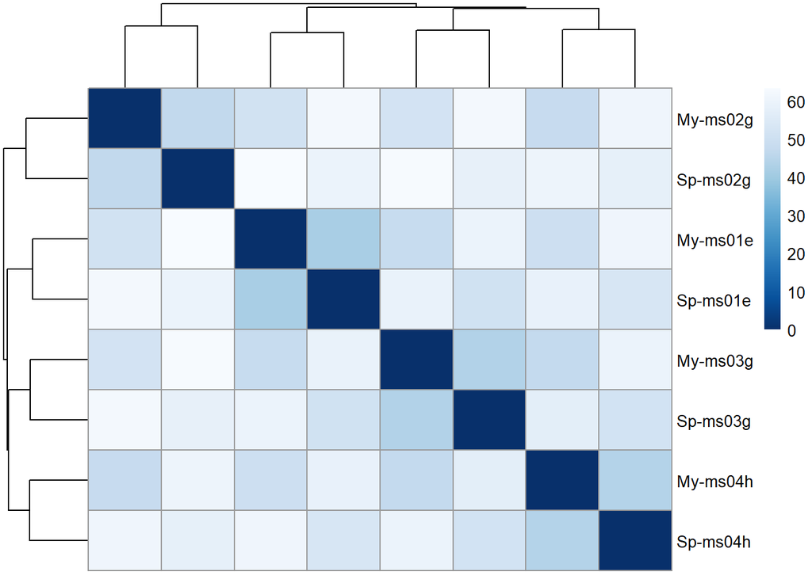

```r
pheatmap(sampleDistMatrix,
         clustering_distance_rows = sampleDists.ASE_Matrix,
         clustering_distance_cols = sampleDists.ASE_Matrix,
         col = colors)
```

#### Prepare Dataframe for ggplot heatmap

```r
sampleDistDF <- as.data.frame(sampleDistMatrix)
colnames(sampleDistDF) <- c("My-ms01e", "Sp-ms01e", "My-ms02g", "Sp-ms02g",
                                   "My-ms03g", "Sp-ms03g", "My-ms04h", "Sp-ms04h")

# Make columns from rownames
sampleDistDF$sample_1 <- rownames(sampleDistDF)

# Make long-format data frame
sampleDistDF <- sampleDistDF %>%
  pivot_longer(!sample_1,
               names_to = "sample_2",
               values_to = "dist")
```

#### GGplot Heatmap

```r
# GGplot Heatmap Distances
grDevices::png(filename = "htmp_dist.png",  width = 12.5, height = 8, units = 'cm', res = 400)

htmp_dist <- ggplot(sampleDistDF, aes(sample_1, sample_2, fill = dist)) +
  geom_tile() +
  scale_fill_gradient(low = "#457b92", high = "#f5ffff") +
  labs(title = "Heatmap: sample distances") +
  theme_minimal() +
  theme(
    axis.title.x = element_blank(),
    axis.title.y = element_blank(),
    legend.title = element_blank(),
    plot.title = element_text(size = 12),
    axis.text.x = element_text(angle = 45, hjust=1)
  )

htmp_dist

dev.off()
```

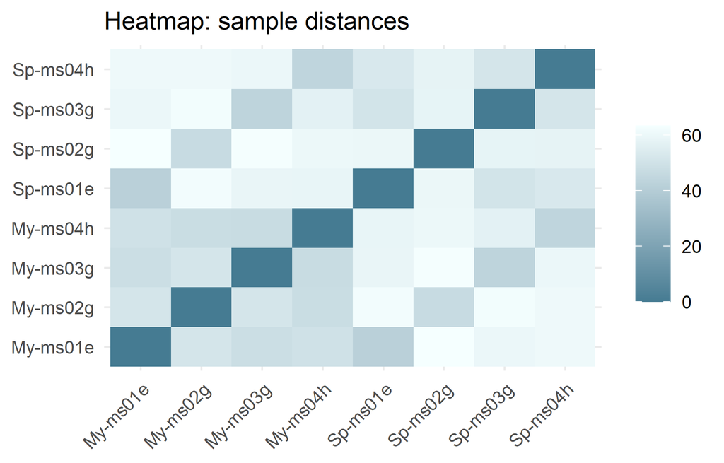

```r
knitr::include_graphics("htmp_dist.png")
```

### C-02 III : sample distances heatMap using poission

# this function takes original count matrix (not normalized) with samples as rows

```r
poisDists <- PoissonDistance(t(counts(ASE_Matrix)))
samplePoisDistMatrix <- as.matrix(poisDists$dd)

rownames(samplePoisDistMatrix) <- paste(
  rld.ASE_Matrix$hapType, rld.ASE_Matrix$sampleID, sep = "-")

colnames(samplePoisDistMatrix) <- NULL

samplePoisDistMatrix
```

```
##               [,1]      [,2]      [,3]      [,4]      [,5]      [,6]     [,7]
## My-ms01e    0.0000  500.7647  697.9457 1062.0223  624.6305  962.4118 649.6450
## Sp-ms01e  500.7647    0.0000 1068.3020  954.9788  931.9396  716.0597 933.0843
## My-ms02g  697.9457 1068.3020    0.0000  630.8040  747.1794 1080.7018 659.1200
## Sp-ms02g 1062.0223  954.9788  630.8040    0.0000 1086.9830  924.2734 997.0650
## My-ms03g  624.6305  931.9396  747.1794 1086.9830    0.0000  529.0677 597.6537
## Sp-ms03g  962.4118  716.0597 1080.7018  924.2734  529.0677    0.0000 877.0273
## My-ms04h  649.6450  933.0843  659.1200  997.0650  597.6537  877.0273   0.0000
## Sp-ms04h  978.3080  742.6169 1020.0877  900.0103  928.6833  690.0129 508.5604
##               [,8]
## My-ms01e  978.3080
## Sp-ms01e  742.6169
## My-ms02g 1020.0877
## Sp-ms02g  900.0103
## My-ms03g  928.6833
## Sp-ms03g  690.0129
## My-ms04h  508.5604
## Sp-ms04h    0.0000
```

#### Standard heatmap (Poisson distances)

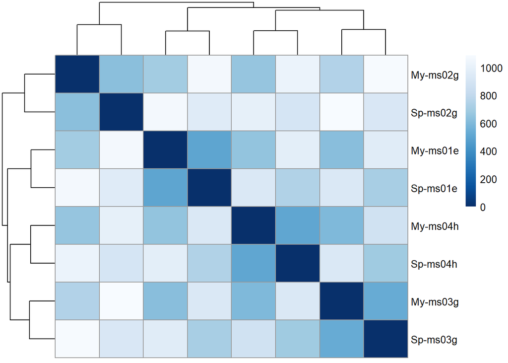

```r
pheatmap(samplePoisDistMatrix,
         clustering_distance_cols = poisDists$dd,
         clustering_distance_rows = poisDists$dd,
         col = colors)
```

#### Prepare Dataframe for ggplot heatmap

```r
samplePoisDistDF <- as.data.frame(samplePoisDistMatrix)
colnames(samplePoisDistDF) <- c("My-ms01e", "Sp-ms01e", "My-ms02g", "Sp-ms02g",
                                   "My-ms03g", "Sp-ms03g", "My-ms04h", "Sp-ms04h")

# Make columns frow rownames
samplePoisDistDF$sample_1 <- rownames(samplePoisDistDF)

# Make long-format data frame
samplePoisDistDF <- samplePoisDistDF %>%
  pivot_longer(!sample_1,
               names_to = "sample_2",
               values_to = "pois_dist")
```

#### GGplot Heatmap Poisson Distances

```r
grDevices::png(filename = "htmp_pois_dist.png",  width = 12.5, height = 8, units = 'cm', res = 400)

htmp_pois_dist <- ggplot(samplePoisDistDF, aes(sample_1, sample_2, fill = pois_dist)) +
  geom_tile() +
  scale_fill_gradient(low = "#457b92", high = "#f5ffff") +
  labs(title = "Heatmap: samples poisson distances") +
  theme_minimal() +
  theme(
    axis.title.x = element_blank(),
    axis.title.y = element_blank(),
    legend.title = element_blank(),
    plot.title = element_text(size = 12),
    axis.text.x = element_text(angle = 45, hjust=1)
  )

htmp_pois_dist
dev.off()
```

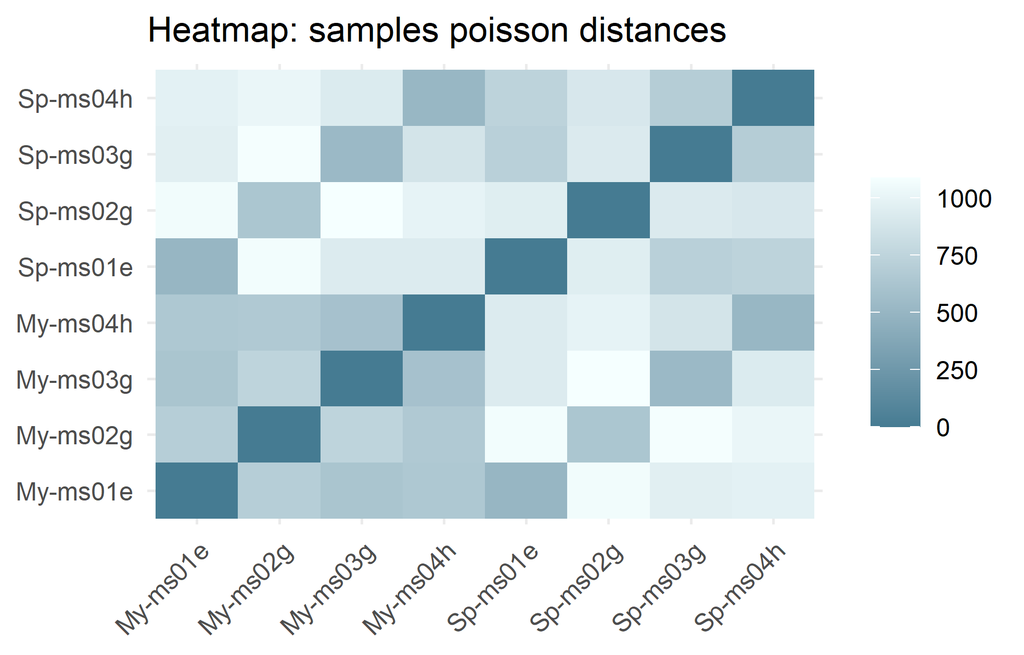

```r
knitr::include_graphics("htmp_pois_dist.png")
```

## Step C-03: PCA plot

Another way to visualize sample distances is PCA plot. Here the data points are projected on a 2D plane on which one plane explains the most variation while the other plane might explain second most variation

### C-03.I:

#### PCA results

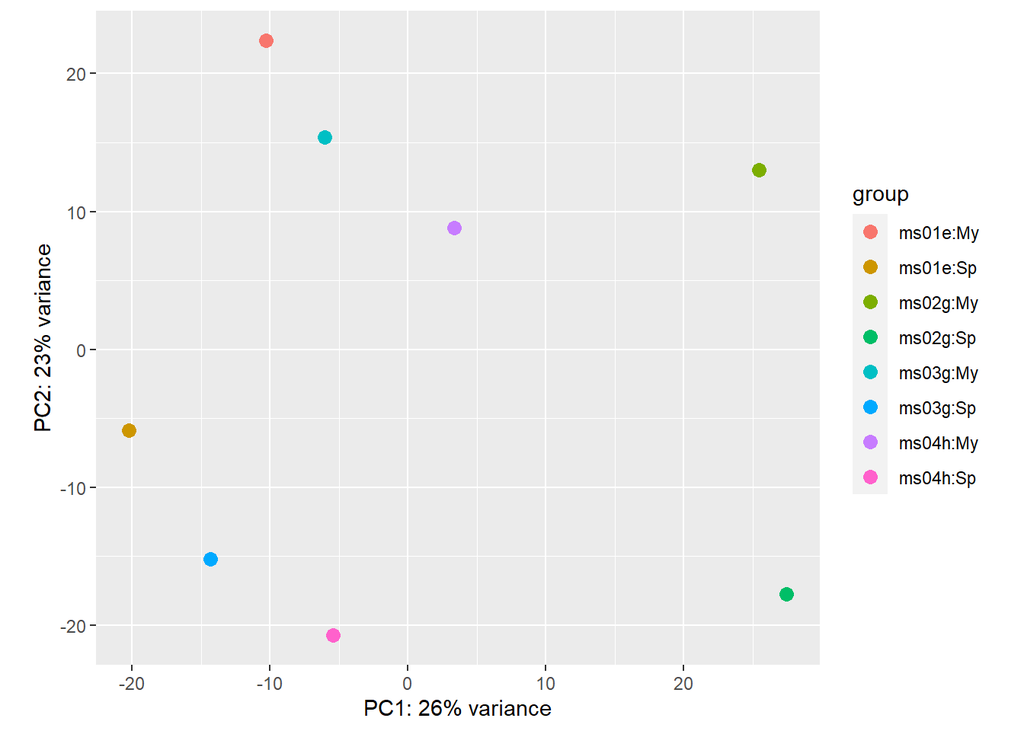

```r
# Save the results of pca as dataframe
PcaDF <- plotPCA(rld.ASE_Matrix, intgroup = c("sampleID", "hapType"), returnData = TRUE)

# Plot pca-plot using DESeq2 package
plotPCA(rld.ASE_Matrix, intgroup = c("sampleID", "hapType"))
```

#### GGplot PCA

```r
grDevices::png(filename = "pca.png",  width = 12.5, height = 8, units = 'cm', res = 400)

pca <- ggplot(PcaDF,aes(x = PC1,y = PC2,
                       color = group,
                       shape = group)
) +
  # Make a scatter plot
  geom_point(size = 4) +
  scale_color_manual("Sample:hapType",
                     values = c("#E63946","#457b92", "#E63946","#457b92", "#E63946","#457b92", "#E63946", "#457b92")) +
  scale_shape_manual("Sample:hapType",
                     values = c(19, 19, 17, 17, 15, 15, 3, 3)) +
  labs(
    title = "PCA",
    y = "PC2: 23% variance",
    x = "PC1: 26% variance"
  ) +
  theme_bw() +
  theme(
    panel.grid.major = element_line(colour = 'grey85', size = 0.2),
    panel.grid.minor = element_line(colour = 'grey90', size = 0.1),
    axis.title.x = element_text(size = 10),
    axis.title.y = element_text(size = 10),
    plot.title = element_text(size = 12),
    #legend.position = c(0.8,0.2), #You can adjust legend position here
    #legend.background = element_rect(color = "black")
  )

pca

dev.off()
```

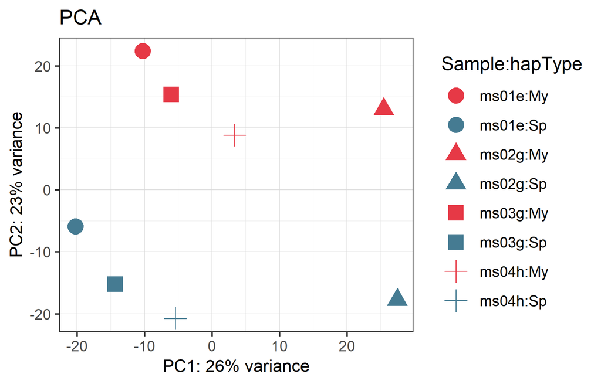

```r
knitr::include_graphics("pca.png")
```

## Step C-04 (**Optional): MDS plot - may be skipped in the pipeline

This is very similar to PCA plot. We use MDS (multidimensional scaling) function R base. This is useful when we don’t have matrix of data of matrix of distances.

### C-04.I : MDS using matrix distance

#### Prepare Dataframe for MDS plot

```r
mds <- as.data.frame(colData(rld.ASE_Matrix))  %>%
  cbind(cmdscale(sampleDistMatrix)) %>%
  mutate(group = paste0(sampleID, ":", hapType))
```

#### GGplot MSD plot

```r
grDevices::png(filename = "mds.png",  width = 12.5, height = 8, units = 'cm', res = 400)

mds_plot <- ggplot(mds, aes(x = `1`, y = `2`, color = group, shape = group)) +
  geom_point(size = 4) +
  scale_color_manual("Sample:hapType",
                     values = c("#E63946","#457b92", "#E63946","#457b92", "#E63946","#457b92", "#E63946", "#457b92")) +
  scale_shape_manual("Sample:hapType",
                     values = c(19, 19, 17, 17, 15, 15, 3, 3)) +
  coord_fixed() +
  labs(
    title = "MDS"
    #y = "",
    #x = ""
  ) +
  theme_bw() +
  theme(
    panel.grid.major = element_line(colour = 'grey85', size = 0.2),
    panel.grid.minor = element_line(colour = 'grey90', size = 0.1),
    axis.title.x = element_text(size = 10),
    axis.title.y = element_text(size = 10),
    plot.title = element_text(size = 12)
    #legend.position = c(0.8,0.2), #You can adjust legend position here
    #legend.background = element_rect(color = "black")
  )

mds_plot

dev.off()
```

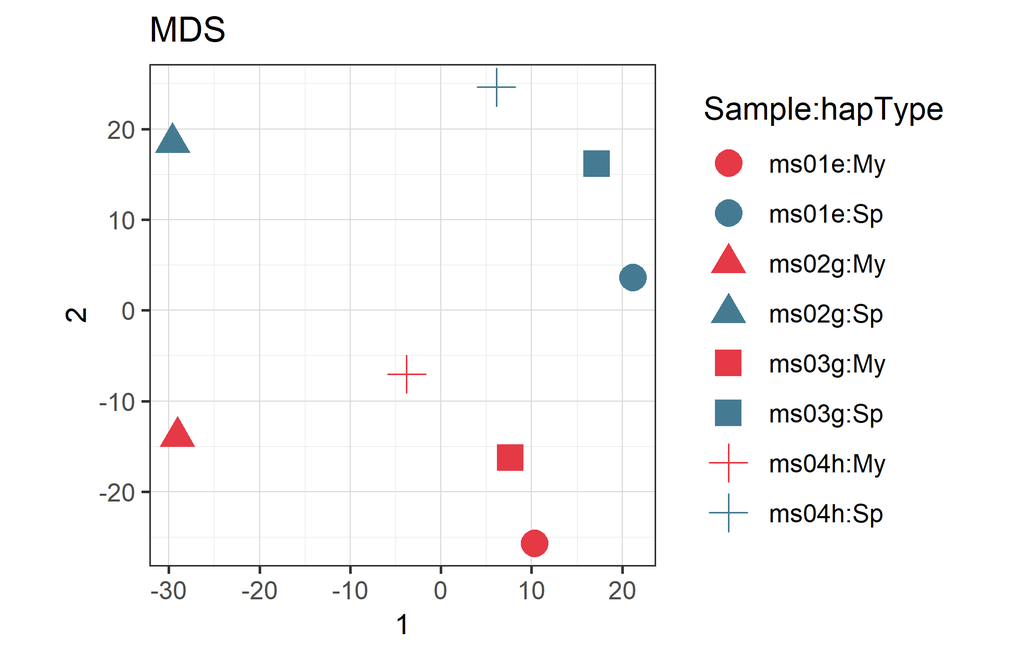

```r
knitr::include_graphics("mds.png")
```

### C-04.II : MDS using poission distance

#### Prepare Dataframe for MDS plot with poisson distances

```r
mdsPois <- as.data.frame(colData(ASE_Matrix)) %>%
  cbind(cmdscale(samplePoisDistMatrix)) %>%
  mutate(group = paste0(sampleID, ":", hapType))
```

#### GGplot MSD with Poisson Distances

```r
grDevices::png(filename = "mds_pois.png",  width = 12.5, height = 8, units = 'cm', res = 400)

mds_pois <-  ggplot(mdsPois, aes(x = `1`, y = `2`, color = group, shape = group)) +
  geom_point(size = 4) +
  scale_color_manual("Sample:hapType",
                     values = c("#E63946","#457b92", "#E63946","#457b92", "#E63946","#457b92", "#E63946", "#457b92")) +
  scale_shape_manual("Sample:hapType",
                     values = c(19, 19, 17, 17, 15, 15, 3, 3)) +
  coord_fixed() +
  labs(
    title = "MDS: Poisson distances"
    #y = "",
    #x = ""
  ) +
  theme_bw() +
  theme(
    panel.grid.major = element_line(colour = 'grey85', size = 0.2),
    panel.grid.minor = element_line(colour = 'grey90', size = 0.1),
    axis.title.x = element_text(size = 10),
    axis.title.y = element_text(size = 10),
    plot.title = element_text(size = 12),
    #legend.position = c(0.8,0.2), #You can adjust legend position here
    #legend.background = element_rect(color = "black")
  )

mds_pois

dev.off()
```

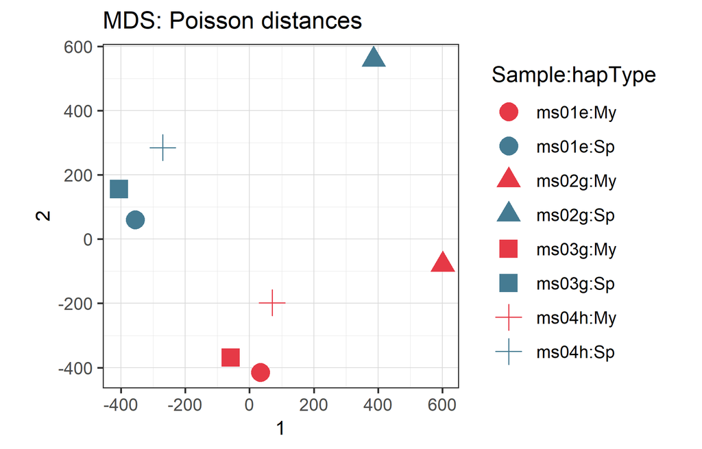

```r
knitr::include_graphics("mds_pois.png")
```

## Step C-05: Check genes with high expression for both haplotypes

### Step C-05 I: Prepare data

#### Calculate unqC_Sum quartiles for each of the samples

```r
quantsDF <- counts.ForBinom %>%
  group_by(sample) %>%
  summarise(q1 = quantile(unqC_Sum, probs = 0.25),
            q2 = quantile(unqC_Sum, probs = 0.50),
            q3 = quantile(unqC_Sum, probs = 0.75))

quantsDF
```

```
## # A tibble: 4 x 4
##   sample    q1    q2    q3
##   <chr>  <dbl> <dbl> <dbl>
## 1 2ms01e   146   430 1074
## 2 2ms02g   152   486 1136
## 3 2ms03g   142   404 1050
## 4 2ms04h   134   436 1060.
```

#### Left join 3rd Quarile threshold and check if unqC_sum (unqC_My + unqC_Sp) lie in the 4th quartile

```r
countsWithQuants <- counts.ForBinom %>%
  left_join(quantsDF %>% dplyr::select(sample, q3), by = "sample") %>%
  mutate(high_exp = ifelse(unqC_Sum >= q3, 1, 0))
```

#### See some summary stats

```r
countsWithQuants %>% group_by(sample) %>%
  summarise(n = sum(high_exp))
```

```
## # A tibble: 4 x 2
##   sample     n
##   <chr>  <dbl>
## 1 2ms01e   396
## 2 2ms02g   389
## 3 2ms03g   400
## 4 2ms04h   399
```

#### List of unique genes with high expression for each sample

```r
high_exp_01 <- subset(countsWithQuants, sample == "2ms01e" & high_exp == 1)$transcript_ID
high_exp_02 <- subset(countsWithQuants, sample == "2ms02g" & high_exp == 1)$transcript_ID
high_exp_03 <- subset(countsWithQuants, sample == "2ms03g" & high_exp == 1)$transcript_ID
high_exp_04 <- subset(countsWithQuants, sample == "2ms04h" & high_exp == 1)$transcript_ID

#list of lists with genes for each sample
input_high_exp <- list("2ms01e" = high_exp_01, "2ms02g" = high_exp_02, "2ms03g" =high_exp_03, "2ms04h" = high_exp_04)
```

### C-05 II: Venn plot of genes which have overall expression > 3rd quartile

#### Needed package

```r
library(ggvenn)
```

#### Venn plot

```r
grDevices::png(filename = "venn_high_exp.png",  width = 12.5, height = 8, units = 'cm', res = 400)

venn_high_exp <-ggvenn(
  input_high_exp,
  fill_color = c("#0073C2FF", "#EFC000FF", "#868686FF", "#CD534CFF"),
  stroke_size = 0.4, set_name_size = 3, text_size = 3
  )

venn_high_exp

dev.off()
```

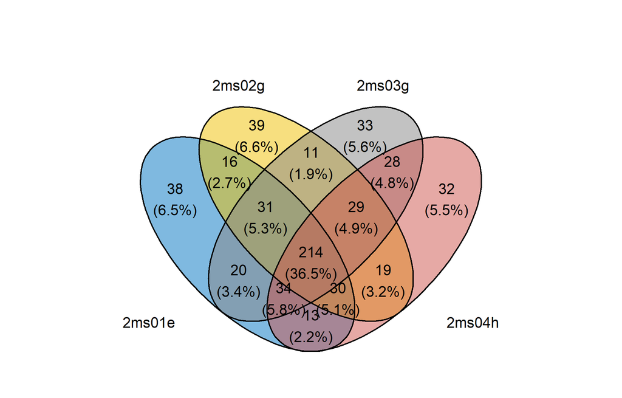

```r
knitr::include_graphics("venn_high_exp.png")
```

# Part D: Binomial Tests

## Step D-01: Run binomial test

```r
counts.ForBinom$binom_p = apply(counts.ForBinom[,c("unqC_My", "unqC_Sp")],
                     1, function(x)binom.test(x[1],x[1]+x[2],p=0.5, alternative = "two.sided")$p.value)
```

## Step D-02: Obtain Results of binomial tests

```r
counts.ForBinom$p0.05 <- ifelse(counts.ForBinom$binom_p < 0.05, 1, 0)
counts.ForBinom$p0.01 <- ifelse(counts.ForBinom$binom_p < 0.01, 1, 0)
counts.ForBinom$p0.001 <- ifelse(counts.ForBinom$binom_p < 0.001, 1, 0)
```

# Part E: ASE analyses (modified DESeq method)

## Step E-01: Run the DESeq using the design

```r
dds.ASE_Data <- DESeq(ASE_Matrix, fitType = "local", betaPrior = FALSE)
```

## Step E-02: Build the results table

Details: Calling results without any arguments will extract the estimated log2 fold changes and p values for the last variable in the design formula. If there are more than 2 levels for this variable { as is the case in this analysis { results will extract the results table for a comparison of the last level over the first level.

#### Dataset with results

```r
# Set "Sp" counts as the reference level
result.ASE_Data <- results(
  dds.ASE_Data, contrast = c("hapType", "My", "Sp"),
  alpha = 0.05)
```

#### Number of genes with significant difference (TRUE) and insignificant difference (FALSE)

```r
table(result.ASE_Data$padj < 0.1)
```

```
##
## FALSE  TRUE
##  1191   570
```

```r
summary(result.ASE_Data)
```

```
##
## out of 1761 with nonzero total read count
## adjusted p-value < 0.05
## LFC > 0 (up)       : 267, 15%
## LFC < 0 (down)     : 191, 11%
## outliers [1]       : 0, 0%
## low counts [2]     : 0, 0%
## (mean count < 2)
## [1] see 'cooksCutoff' argument of ?results
## [2] see 'independentFiltering' argument of ?results
```

## Step E-03 (**Optional):

If we want to make the sig genes threshold more stricter we can narrow down padj and/or also use higher L2FC

### E-03 I: LFC Threshold == 1 & adjusted p-value < 0.05

#### Obtain results

```r
result.ASE_Data.05 <- results(
  dds.ASE_Data, contrast = c("hapType", "My", "Sp"),
  alpha = 0.05, lfcThreshold = 1)
```

#### Summary of the results

```r
table(result.ASE_Data.05$padj < 0.05)
```

```
##
## FALSE  TRUE
##  1605    94
```

```r
summary(result.ASE_Data.05)
```

```
##
## out of 1761 with nonzero total read count
## adjusted p-value < 0.05
## LFC > 1.00 (up)    : 62, 3.5%
## LFC < -1.00 (down) : 32, 1.8%
## outliers [1]       : 0, 0%
## low counts [2]     : 62, 3.5%
## (mean count < 6)
## [1] see 'cooksCutoff' argument of ?results
## [2] see 'independentFiltering' argument of ?results
```

### E-03 II: LFC Threshold == 1

(**Optional): If we want the results that have gene expression at least double or halving in My i.e lfc of 1 is 2^1 = 2 (double the expression)

#### Obtain Results

```r
result.ASE_Data.LFC1 <- results(dds.ASE_Data, lfcThreshold = 1,
                                contrast = c("hapType", "My", "Sp"))
```

#### Summary of the results

```r
table(result.ASE_Data.LFC1$padj < 0.05)
```

```
##
## FALSE  TRUE
##  1670    91
```

```r
summary(result.ASE_Data.LFC1)
```

```
##
## out of 1761 with nonzero total read count
## adjusted p-value < 0.1
## LFC > 1.00 (up)    : 64, 3.6%
## LFC < -1.00 (down) : 35, 2%
## outliers [1]       : 0, 0%
## low counts [2]     : 0, 0%
## (mean count < 2)
## [1] see 'cooksCutoff' argument of ?results
## [2] see 'independentFiltering' argument of ?results
```

## Step E-04: Convert the results table to dataframe.

#### Reslts

```r
# Results as dataframe
result.ASE.asDF <- as.data.frame(result.ASE_Data)
result.ASE.LFC1.asDF <- as.data.frame(result.ASE_Data.LFC1)

result.ASE.asDF <- rownames_to_column(
  result.ASE.asDF, var = "transcript_ID")
result.ASE.LFC1.asDF <- rownames_to_column(
  result.ASE.LFC1.asDF , var = "transcript_ID")

head(result.ASE.asDF)
```

```
##   transcript_ID baseMean log2FoldChange     lfcSE       stat       pvalue
## 1  AL2G10020.t1  1748.25     -2.2956110 1.2112172 -1.8952925 0.0580536565
## 2  AL2G10030.t1  1089.75      0.6501060 0.1675992  3.8789320 0.0001049161
## 3  AL2G10050.t1   160.25      0.7450848 0.8984919  0.8292616 0.4069564221
## 4  AL2G10060.t1    50.00      0.6378227 0.4900287  1.3016026 0.1930522825
## 5  AL2G10070.t1    23.75     -0.9689420 0.7103124 -1.3641068 0.1725339419
## 6  AL2G10080.t1    47.75      0.1333075 0.3683307  0.3619235 0.7174092155
##           padj
## 1 0.1577661868
## 2 0.0009521844
## 3 0.6059248002
## 4 0.3687256720
## 5 0.3421738043
## 6 0.8530493180
```

```r
head(result.ASE.LFC1.asDF)
```

```
##   transcript_ID baseMean log2FoldChange     lfcSE      stat    pvalue padj
## 1  AL2G10020.t1  1748.25     -2.2956110 1.2112172 -1.069677 0.2847648    1
## 2  AL2G10030.t1  1089.75      0.6501060 0.1675992  0.000000 1.0000000    1
## 3  AL2G10050.t1   160.25      0.7450848 0.8984919  0.000000 1.0000000    1
## 4  AL2G10060.t1    50.00      0.6378227 0.4900287  0.000000 1.0000000    1
## 5  AL2G10070.t1    23.75     -0.9689420 0.7103124  0.000000 1.0000000    1
## 6  AL2G10080.t1    47.75      0.1333075 0.3683307  0.000000 1.0000000    1
```

## Step E-05: Venn plot comparing general ASE results and ASE results with threshold

#### Prepare data for Venn plot

```r
sign_results <- subset(result.ASE.asDF, padj <= 0.001)$transcript_ID
sign_results_lfc1 <-subset(result.ASE.LFC1.asDF, padj <= 0.001)$transcript_ID

input_ase_results <- list("No threshold" = sign_results, "LFC Threshold = 1" = sign_results_lfc1)
```

#### Venn plot

```r
grDevices::png(filename = "venn_ase_sign.png",  width = 12.5, height = 8, units = 'cm', res = 400)

venn_ase_sign <- ggvenn(
  input_ase_results,
  fill_color = c("#0073C2FF", "#EFC000FF"),
  stroke_size = 0.4, set_name_size = 3, text_size = 3
)

venn_ase_sign

dev.off()
```

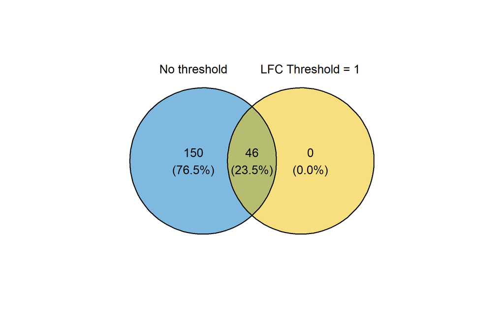

```r
knitr::include_graphics("venn_ase_sign.png")
```

Results: basically, the results seem to be obvious. When applying a threshold we simply have lower number of genes with adjusted p-value on the same level.

# Part F: Plotting results

## Step F-01: Before we start plotting we add some extra information to the results table

This extra step helps to add more metadata information to the “results” for better analyses and plotting

### Step F-01.I : update the data/matrix with geneNames, geneID

- We can use biomart
- Or a simple column merge (by matching row names) - We use this :)

#### create geneMap database

```r
geneMap <- counts.ms1e2g3g4h.filt01 %>%
  distinct(start, transcript_ID, .keep_all = TRUE) %>%
  data.frame(row.names = "transcript_ID") %>%
  mutate(
    unqC_My.total = (unqC_My.ms01e + unqC_My.ms02g + unqC_My.ms03g + unqC_My.ms04h),
    unqC_Sp.total = (unqC_Sp.ms01e + unqC_Sp.ms02g + unqC_Sp.ms03g + unqC_Sp.ms04h)) %>%
  select(contig, start, end, gene_Name, gene_ID, unqC_My.total, unqC_Sp.total)
# Note: this geneMap database should have exact same number of rows as "results"
# plus the "rownames" should match between "results" and "geneMap"

head(geneMap)
```

```
##              contig start   end gene_Name   gene_ID unqC_My.total unqC_Sp.total
## AL2G10020.t1      2  1116  3595         - AL2G10020          3974         10012
## AL2G10030.t1      2  5226  7090       CP5 AL2G10030          5426          3292
## AL2G10050.t1      2 22602 24361         - AL2G10050           582           700
## AL2G10060.t1      2 29596 30510         - AL2G10060           242           158
## AL2G10070.t1      2 46995 48041       BLT AL2G10070            68           122
## AL2G10080.t1      2 48700 50081         - AL2G10080           188           194
```

### Step F-01.II :now merge this geneMap with resultsData using row.names match.

```r
result.ASE_Data.withGeneMap <- cbind(result.ASE_Data, geneMap)
# Result/Note: this geneMap database should have exact same number of rows as "results"
# plus the "rownames" should match between "results" and "geneMap"
```

#### Just check the number of rows

```r
nrow(result.ASE_Data) == nrow(result.ASE_Data.withGeneMap)
```

```
## [1] TRUE
```

#### Additionally: make a data frame of geneMap and resultsData from S4 object

```r
result.withGeneMap.asDF <- as.data.frame(result.ASE_Data.withGeneMap,
  row.names = rownames(result.ASE_Data.withGeneMap))

result.withGeneMap.asDF <-
  mutate(result.withGeneMap.asDF,
         Significance = if_else(padj <= 0.01 & abs(log2FoldChange) >= 4, "|L2FC| > 4 & padj < 0.01",
                       if_else(padj <= 0.05 & abs(log2FoldChange) >= 2, "|L2FC| > 2 & padj < 0.05", "non-Sig")),
         unqC_total = unqC_My.total + unqC_Sp.total)
```

Now, we start making plot either using “results” table or updated results table

## Step F-02 : Counts plot - using raw counts

Plot of the raw read counts stratified by two haplotypes for specific gene

topGene, PIN1, PIN3, TCP15 - Plot

### Step F-02.I :COunt plot - Top gene (gene with the lowers p-value adjusted)

#### Top gene - DAta

```r
topGene.data <- plotCounts(dds.ASE_Data, gene=which.min(result.ASE_Data.withGeneMap$padj),
                intgroup="hapType", returnData=TRUE)
```

#### See which gene it is

```r
result.withGeneMap.asDF %>%
  filter(padj == min(padj))
```

```
##              baseMean log2FoldChange     lfcSE     stat       pvalue
## AL2G19580.t1      371       2.599961 0.1739049 14.95048 1.546286e-50
##                     padj contig   start     end gene_Name   gene_ID
## AL2G19580.t1 2.72301e-47      2 7856651 7857947         - AL2G19580
##              unqC_My.total unqC_Sp.total             Significance unqC_total
## AL2G19580.t1          2544           424 |L2FC| > 2 & padj < 0.05       2968
```

#### Top gene - plot

```r
grDevices::png(filename = "top_gene.png",  width = 12.5, height = 8, units = 'cm', res = 400)

top_gene <- ggplot(topGene.data, aes(x = hapType, y = count, color = sampleID, group = sampleID)) +
  scale_y_log10() + geom_point(size = 2, position=position_dodge(0.4)) +
  geom_line(position=position_dodge(0.4), size = 1) +
  labs(title = "Raw counts for the Gene with the least p-vaue",
       x = "Haplotype", y = "Raw counts") +
  scale_color_manual("Sample", values = c("#7F58AF", "#64C5EB", "#E84D8A", "#FEB326")) +
  scale_x_discrete(limits = c("Sp", "My")) +
  theme_bw() +
  theme(axis.text=element_text(size=12),
        axis.title=element_text(size=10),
        plot.title = element_text(size = rel(1)),
        panel.grid.major = element_line(colour = 'grey85', size = 0.2),
        panel.grid.minor = element_line(colour = 'grey90', size = 0.1),
        axis.title.x = element_text(size = 10),
        axis.title.y = element_text(size = 10),
        #legend.position = c(0.8,0.2), #You can adjust legend position here
        #legend.background = element_rect(color = "black")
  )


top_gene

dev.off()
```

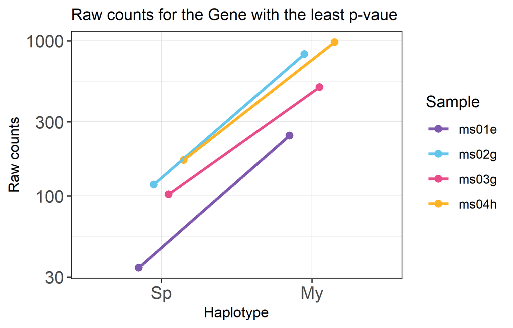

```r
knitr::include_graphics("top_gene.png")
```

Result: this plots the raw counts by Haplotype for the given gene the points are jittered to prevent overlaps the lines are connected between Haplotypes of same samples.

### Step F-02.II: Count plot for PIN3

#### PIN3 - Data

```r
d.PIN3 <- plotCounts(
  dds.ASE_Data,
  gene=which(result.ASE_Data.withGeneMap$gene_Name == "PIN3"),
  intgroup="hapType", returnData=TRUE)
```

#### PIN3 - Plot

```r
grDevices::png(filename = "pin3.png",  width = 12.5, height = 8, units = 'cm', res = 400)

pin3 <- ggplot(d.PIN3, aes(x = hapType, y = count, color = sampleID, group = sampleID)) +
  scale_y_log10() +  geom_point(size = 2, position=position_dodge(0.4)) +
  geom_line(position=position_dodge(0.4), size = 1) +
  labs(title = "Raw counts for PIN3",
       x = "Haplotype", y = "Raw counts") +
  scale_color_manual("Sample", values = c("#7F58AF", "#64C5EB", "#E84D8A", "#FEB326")) +
  theme_bw() +
  theme(axis.text=element_text(size=12),
        axis.title=element_text(size=10),
        plot.title = element_text(size = rel(1)),
        panel.grid.major = element_line(colour = 'grey85', size = 0.2),
        panel.grid.minor = element_line(colour = 'grey90', size = 0.1),
        axis.title.x = element_text(size = 10),
        axis.title.y = element_text(size = 10),
        #legend.position = c(0.8,0.2), #You can adjust legend position here
        #legend.background = element_rect(color = "black")
  )

pin3

dev.off()
```

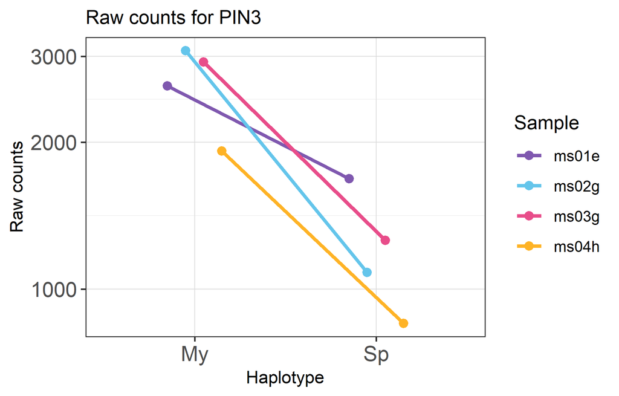

```r
knitr::include_graphics("pin3.png")
```

#### PIN3 - p-value

```r
subset(result.withGeneMap.asDF, gene_Name == "PIN3")$padj
```

```
## [1] 1.053251e-07
```

### Step F-02.III: Count plot for PIN1

#### PIN1 - Data

```r
d.PIN1 <- plotCounts(
  dds.ASE_Data,
  gene=which(result.ASE_Data.withGeneMap$gene_Name == "PIN1"),
  intgroup="hapType", returnData=TRUE)
```

#### PIN1 - Plot

```r
grDevices::png(filename = "pin1.png",  width = 12.5, height = 8, units = 'cm', res = 400)

pin1 <- ggplot(d.PIN1, aes(x = hapType, y = count, color = sampleID, group = sampleID)) +
  scale_y_log10() +  geom_point(size = 2, position=position_dodge(0.4)) +
  geom_line(position=position_dodge(0.4), size = 1) +
  labs(title = "Raw counts for PIN1",
       x = "Haplotype", y = "Raw counts") +
  scale_color_manual("Sample", values = c("#7F58AF", "#64C5EB", "#E84D8A", "#FEB326")) +
  theme_bw() +
  theme(axis.text=element_text(size=12),
        axis.title=element_text(size=10),
        plot.title = element_text(size = rel(1)),
        panel.grid.major = element_line(colour = 'grey85', size = 0.2),
        panel.grid.minor = element_line(colour = 'grey90', size = 0.1),
        axis.title.x = element_text(size = 10),
        axis.title.y = element_text(size = 10),
        #legend.position = c(0.8,0.2), #You can adjust legend position here
        #legend.background = element_rect(color = "black")
  )

pin1

dev.off()
```

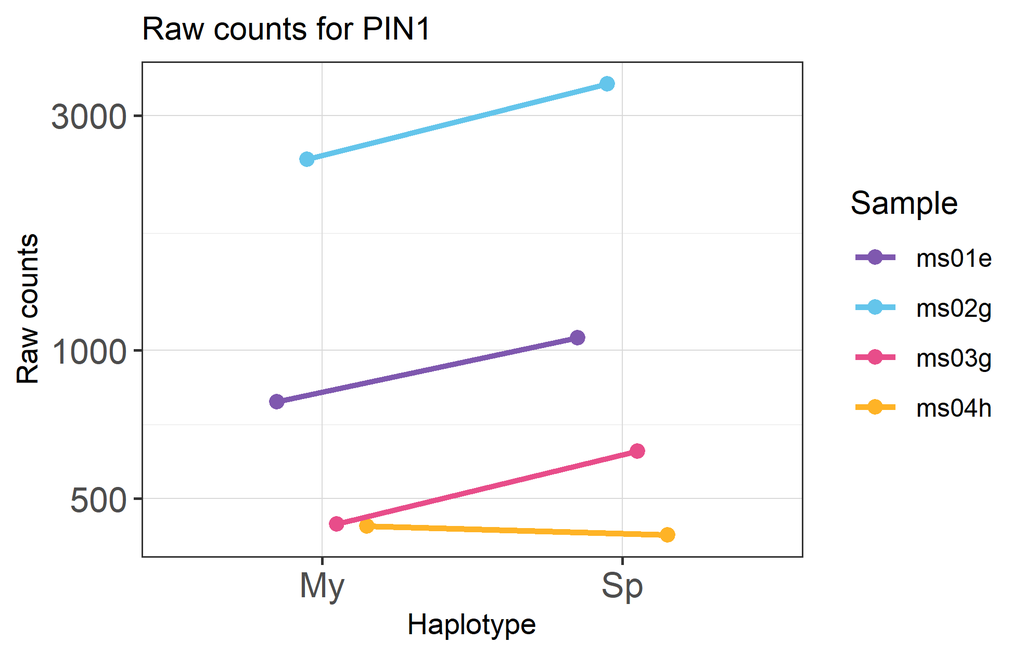

```r
knitr::include_graphics("pin1.png")
```

#### PIN1 - p-value

```r
subset(result.withGeneMap.asDF, gene_Name == "PIN1")$padj
```

```
## [1] 0.0809853
```

### Step F-02.III: Count plot for TCP15

#### TCP15 - Data

```r
d.TCP15 <- plotCounts(
  dds.ASE_Data,
  gene=which(result.ASE_Data.withGeneMap$gene_ID == "AL2G28860"),
  intgroup="hapType", returnData=TRUE)
```

#### TCP15 - Plot

```r
grDevices::png(filename = "tcp15.png",  width = 12.5, height = 8, units = 'cm', res = 400)

tcp15 <- ggplot(d.TCP15, aes(x = hapType, y = count, color = sampleID, group = sampleID)) +
  scale_y_log10() +  geom_point(size = 2, position=position_dodge(0.4)) +
  geom_line(position=position_dodge(0.4), size = 1) +
  labs(title = "Raw counts for TCP15",
       x = "Haplotype", y = "Raw counts") +
  scale_color_manual("Sample", values = c("#7F58AF", "#64C5EB", "#E84D8A", "#FEB326")) +
  scale_x_discrete(limits = c("Sp", "My")) +
  theme_bw() +
  theme(axis.text=element_text(size=12),
        axis.title=element_text(size=10),
        plot.title = element_text(size = rel(1)),
        panel.grid.major = element_line(colour = 'grey85', size = 0.2),
        panel.grid.minor = element_line(colour = 'grey90', size = 0.1),
        axis.title.x = element_text(size = 10),
        axis.title.y = element_text(size = 10),
        #legend.position = c(0.8,0.2), #You can adjust legend position here
        #legend.background = element_rect(color = "black")
  )

tcp15

dev.off()
```

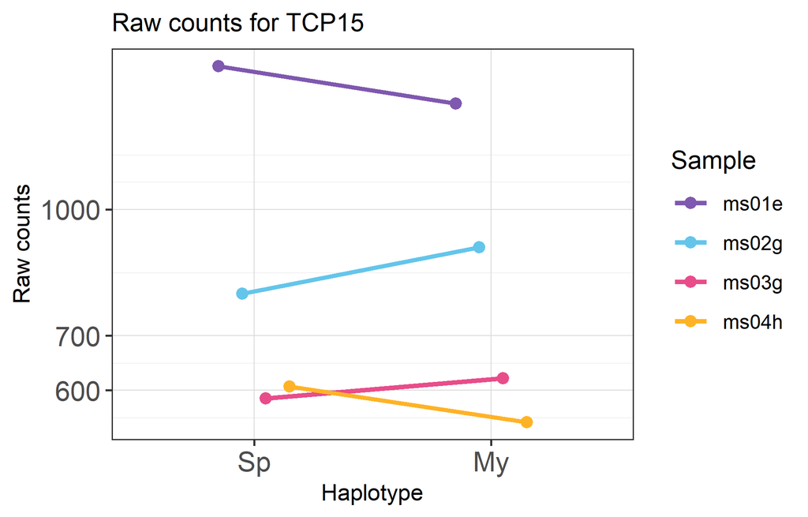

```r
knitr::include_graphics("tcp15.png")
```

#### TCP15 - p-value

```r
subset(result.withGeneMap.asDF, gene_ID == "AL2G28860")$padj
```

```
## [1] 0.9814344
```

### F-02 IV: Count plot for TCP22

#### TCP22 - Data

```r
d.TCP22 <- plotCounts(
  dds.ASE_Data,
  gene=which(result.ASE_Data.withGeneMap$gene_ID == "AL2G31640"),
  intgroup="hapType", returnData=TRUE)
```

#### TCP22 - Plot

```r
grDevices::png(filename = "tcp22.png",  width = 12.5, height = 8, units = 'cm', res = 400)

tcp22 <- ggplot(d.TCP22, aes(x = hapType, y = count, color = sampleID, group = sampleID)) +
  scale_y_log10() +  geom_point(size = 2, position=position_dodge(0.4)) +
  geom_line(position=position_dodge(0.4), size = 1) +
  labs(title = "Raw counts for TCP22",
       x = "Haplotype", y = "Raw counts") +
  scale_color_manual("Sample", values = c("#7F58AF", "#64C5EB", "#E84D8A", "#FEB326")) +
  scale_x_discrete(limits = c("Sp", "My")) +
  theme_bw() +
  theme(axis.text=element_text(size=12),
        axis.title=element_text(size=10),
        plot.title = element_text(size = rel(1)),
        panel.grid.major = element_line(colour = 'grey85', size = 0.2),
        panel.grid.minor = element_line(colour = 'grey90', size = 0.1),
        axis.title.x = element_text(size = 10),
        axis.title.y = element_text(size = 10),
        #legend.position = c(0.8,0.2), #You can adjust legend position here
        #legend.background = element_rect(color = "black")
  )

tcp22

dev.off()
```

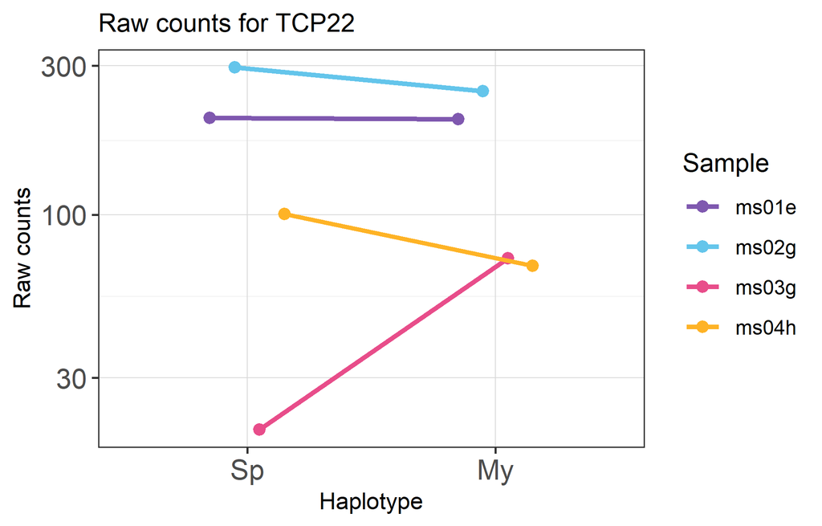

```r
knitr::include_graphics("tcp22.png")
```

#### TCP22 - p-value

```r
subset(result.withGeneMap.asDF, gene_ID == "AL2G31640")$padj
```

```
## [1] 0.8161894
```

### F-02 V: Count plot for AP1

#### AP1 - Data

```r
d.AP1 <- plotCounts(
  dds.ASE_Data,
  gene=which(result.ASE_Data.withGeneMap$gene_ID == "AL2G28180"),
  intgroup="hapType", returnData=TRUE)
```

#### AP1 - Plot

```r
grDevices::png(filename = "ap1.png",  width = 12.5, height = 8, units = 'cm', res = 400)

ap1 <- ggplot(d.AP1, aes(x = hapType, y = count, color = sampleID, group = sampleID)) +
  scale_y_log10() +  geom_point(size = 2, position=position_dodge(0.4)) +
  geom_line(position=position_dodge(0.4), size = 1) +
  labs(title = "Raw counts for AP1",
       x = "Haplotype", y = "Raw counts") +
  scale_color_manual("Sample", values = c("#7F58AF", "#64C5EB", "#E84D8A", "#FEB326")) +
  scale_x_discrete(limits = c("Sp", "My")) +
  theme_bw() +
  theme(axis.text=element_text(size=12),
        axis.title=element_text(size=10),
        plot.title = element_text(size = rel(1)),
        panel.grid.major = element_line(colour = 'grey85', size = 0.2),
        panel.grid.minor = element_line(colour = 'grey90', size = 0.1),
        axis.title.x = element_text(size = 10),
        axis.title.y = element_text(size = 10),
        #legend.position = c(0.8,0.2), #You can adjust legend position here
        #legend.background = element_rect(color = "black")
  )

ap1

dev.off()
```

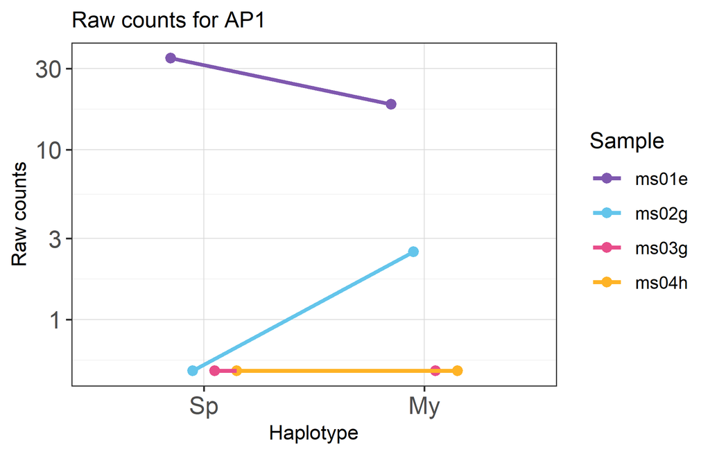

```r
knitr::include_graphics("ap1.png")
```

#### AP1 - p-value

```r
subset(result.withGeneMap.asDF, gene_ID == "AL2G28180")$padj
```

```
## [1] 0.9107402
```

## Step F-03: Prepare Data for Diagnostic Plots

### Step F-03 I. Make significance categories

Here we make categories of genes depending on the Log2FoldChange and p-value adjusted.

In addition, we make separate groups for significance which derived purely according to p-values.

```r
# Make a copy of the DESeq2 results table
result.ASE.copy <- result.ASE.asDF

# -Log10 of p-value adjusted
result.ASE.copy$padj_log10 <- -log10(result.ASE.copy$padj)

# Make groups of genes depending on the
result.ASE.copy <- result.ASE.copy %>%
  mutate(
    cat = case_when(
    log2FoldChange < -0.6 & padj <= 0.05 ~ "Lower",
    log2FoldChange > 0.6 & padj <= 0.05 ~ "Upper",
    TRUE ~ "NS"),
    sign = case_when(
      padj <= 0.001 ~ "< 0.001",
      padj <= 0.01 ~ "< 0.01",
      padj <= 0.05 ~ "< 0.05",
      padj <= 0.1 ~ "< 0.1",
      TRUE ~ "ns")
  )
```

### F-03 II: A brief look on significance categories

#### Check number number of genes in each category

```r
# Check categories
knitr::kable(table(result.ASE.copy$cat))
```

| Var1 | Freq |
| --- | --- |
| Lower | 162 |
| NS | 1377 |
| Upper | 222 |

#### Check number of genes by significance level

We interpret the table as follows:

[output not shown]

```r
knitr::kable(table(result.ASE.copy$sign))
```

| Var1 | Freq |
| --- | --- |
| < 0.001 | 196 |
| < 0.01 | 90 |
| < 0.05 | 172 |
| < 0.1 | 112 |
| ns | 1191 |

#### Plot the number of genes by significance levels

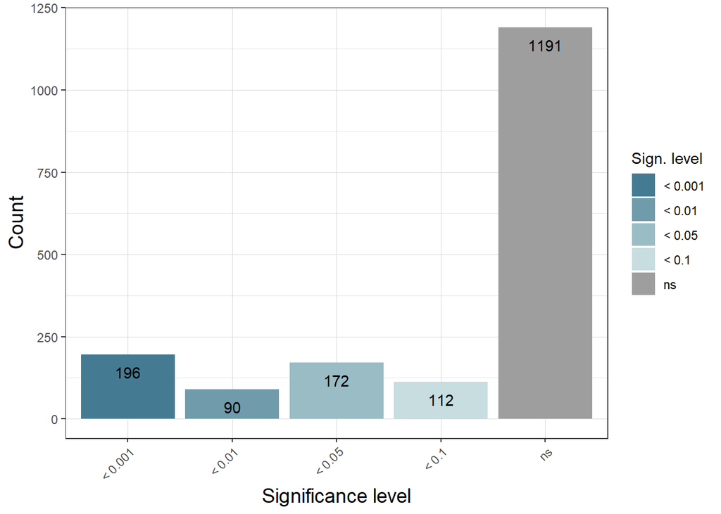

```r
result.ASE.copy %>%
  group_by(sign) %>%
  summarise(n = n()) %>%
  ggplot(aes(x = sign, y = n, fill = sign)) +
  geom_bar(stat = "identity") +
  geom_text(aes(label = n), vjust = 2) +
  labs(x = "Significance level",
       y = "Count") +
  scale_fill_manual("Sign. level",
                    values = c("#457b92", "#6f9baa", "#9abcc4", "#c7dde0", "#9e9e9e")) +
  theme_bw() +
  theme(
    panel.grid.major = element_line(colour = 'grey85', size = 0.2),
    panel.grid.minor = element_line(colour = 'grey90', size = 0.1),
    axis.title.x = element_text(size = 14),
    axis.title.y = element_text(size = 14),
    plot.title = element_text(size = 16),
    axis.text.x = element_text(angle = 45, hjust=1),
    #legend.position = c(0.8,0.2), #You can adjust legend position here
    #legend.background = element_rect(color = "black")
  )
```

## Step F-04: Diagnostic Plots

### F-04 I: Volcano plot

#### Make a volcano plot

```r
grDevices::png(filename = "volc_wald.png",  width = 12.5, height = 8, units = 'cm', res = 400)

# Volcano Plot
volc_wald <- result.ASE.copy %>%
  ggplot(mapping = aes(x = log2FoldChange, y = padj_log10)) +
  geom_point(data = result.ASE.copy %>% filter(cat == "Lower"), aes(color = sign), alpha = 0.9) +
  scale_color_manual("My < Sp", #legend title
                     values = c("#457b92","#7eb1c7","#b8eaff"), #colors for sign_level
                     guide = guide_legend(override.aes = list(size = 4)) #size of the points inside legend
  ) +
  ggnewscale::new_scale_color() + # Need to add new gradient scale
  # Beyond abline
  geom_point(data = result.ASE.copy %>% filter(cat == "Upper"), aes(color = sign), alpha = 0.9) +
  scale_color_manual("My > Sp",
                     values = c("#E63946","#f98e89","#ffd6d2"),
                     guide = guide_legend(override.aes = list(size = 4))
  ) +
  ggnewscale::new_scale_color() +
  # Not significant
  geom_point(data = result.ASE.copy %>% filter(cat == "NS"), aes(color = "Not sign."), size = 1, alpha = 0.8) +
  scale_color_manual("",values= "#525252", labels = "Not sign.",
                     guide = guide_legend(override.aes = list(size = 4))
  ) +
  #ggnewscale::new_scale_color() +
  labs(x = "Log2 Folds Change",
       y = "-log10 p-value",
       title = "Volcano plot") +
  theme_bw() +
  theme(
    panel.grid.major = element_line(colour = 'grey85', size = 0.2),
    panel.grid.minor = element_line(colour = 'grey90', size = 0.1),
    axis.title.x = element_text(size = 10),
    axis.title.y = element_text(size = 10),
    plot.title = element_text(size = 12),
    #legend.key = element_rect(color = "black")
    legend.title = element_text(size = 10),
    legend.text = element_text(size = 10),
    legend.spacing.y = unit(0.05, "cm")
  )

volc_wald

dev.off()
```

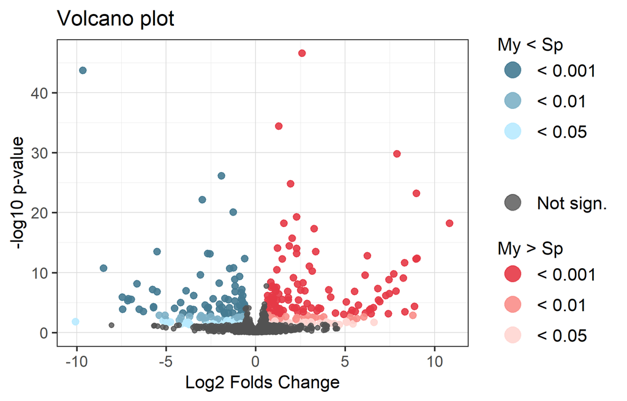

```r
knitr::include_graphics("volc_wald.png")
```

### F-04 II: MA-plot (ggpubr version)

#### Upload the package

```r
library(ggpubr)
```

#### Make MA-plot with ggpubr package

```r
grDevices::png(filename = "ma_pubr.png",  width = 12.5, height = 8, units = 'cm', res = 400)

ma_pubr <- ggpubr::ggmaplot(result.ASE_Data.withGeneMap, fdr = 0.05, fc = 1.5, size = 0.4,
                 main = "MA plot", legend = "top", top = 20,
                 palette = c("#B31B21", "#1465AC", "darkgray"),
                 genenames = as.vector(if_else(result.ASE_Data.withGeneMap$padj < 0.001, result.ASE_Data.withGeneMap$gene_Name, NULL)),
                 font.label = c("bold", 6), font.legend = c("bold", 8), font.main = c("bold", 8),
                 font.x = 8, font.y = 8,
                 ggtheme = ggplot2::theme_bw())

ma_pubr

dev.off()
```

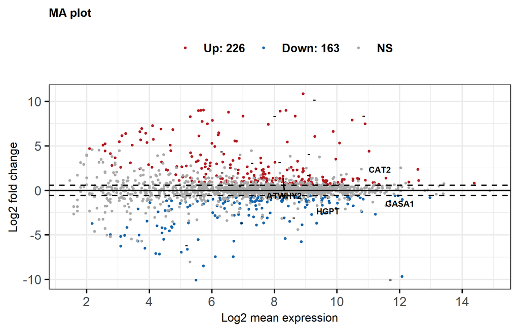

```r
knitr::include_graphics("ma_pubr.png")
```

### F-04 III: MA-plot (ggplot2 version)

```r
grDevices::png(filename = "md_wald.png",  width = 12.5, height = 8, units = 'cm', res = 400)

md_wald <- result.ASE.copy %>%
  ggplot(mapping = aes(y = log2FoldChange, x = baseMean)) +
  geom_point(data = result.ASE.copy %>% filter(cat == "Lower"), aes(color = sign), alpha = 0.9) +
  scale_color_manual("My < Sp", #legend title
                     values = c("#457b92","#7eb1c7","#b8eaff"), #colors for sign_level
                     guide = guide_legend(override.aes = list(size = 4)) #size of the points inside legend
  ) +
  ggnewscale::new_scale_color() + # Need to add new gradient scale
  # Beyond abline
  geom_point(data = result.ASE.copy %>% filter(cat == "Upper"), aes(color = sign), alpha = 0.9) +
  scale_color_manual("My > Sp",
                     values = c("#E63946","#f98e89","#ffd6d2"),
                     guide = guide_legend(override.aes = list(size = 4))
  ) +
  ggnewscale::new_scale_color() +
  # Not significant
  geom_point(data = result.ASE.copy %>% filter(cat == "NS"), aes(color = "Not sign."), size = 1, alpha = 0.8) +
  scale_color_manual("",values= "#525252", labels = "Not sign.",
                     guide = guide_legend(override.aes = list(size = 4))
  ) +
  #ggnewscale::new_scale_color() +
  labs(y = "Log2 Folds Change",
       x = "Log2 mean expression",
       title = "MA Plot") +
  scale_x_continuous(trans = "log2") +
  theme_bw() +
  theme(
    panel.grid.major = element_line(colour = 'grey85', size = 0.2),
    panel.grid.minor = element_line(colour = 'grey90', size = 0.1),
    axis.title.x = element_text(size = 10),
    axis.title.y = element_text(size = 10),
    plot.title = element_text(size = 12),
    #legend.key = element_rect(color = "black")
    legend.title = element_text(size = 10),
    legend.text = element_text(size = 10),
    legend.spacing.y = unit(0.05, "cm")
  )

md_wald

dev.off()
```

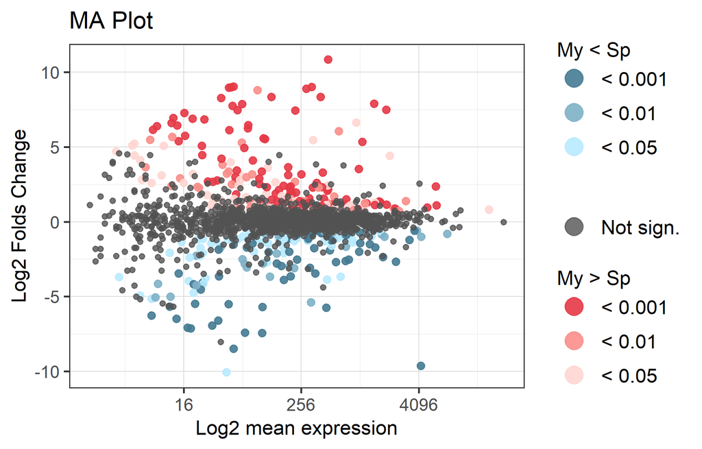

```r
knitr::include_graphics("md_wald.png")
```

### F-04 IV: Additional Plots (not included into the final text)

#### Plot dispersion estimates

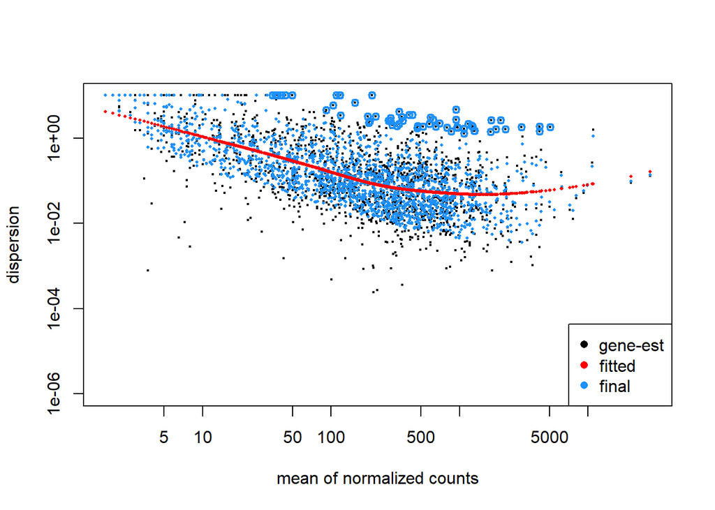

```r
plotDispEsts(dds.ASE_Data, ylim = c(1e-6, 1e1))
```

#### Histogram of p-values

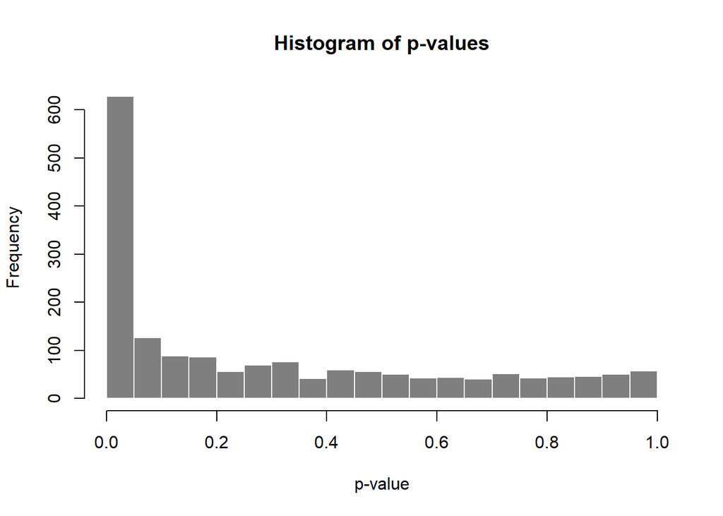

```r
hist( result.ASE_Data.withGeneMap$pvalue,
      breaks=0:20/20, col="grey50", border = "white",
      main = "Histogram of p-values", xlab = "p-value")
```

#### Allelic Expression Balance plot

This plot gene expression (log2FoldChanges i.e ASE) by chromosome and genomic position. Then color the points where the p-adj are significant.

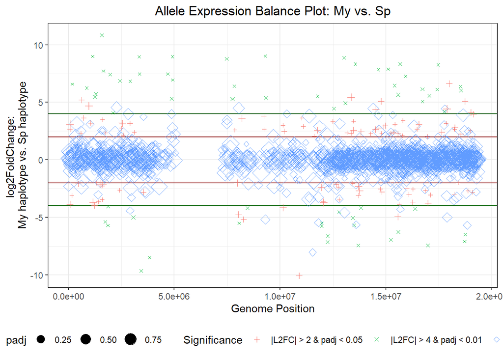

```r
ggplot(result.withGeneMap.asDF, aes(x=start, y= log2FoldChange)) +
  labs(title = "Allele Expression Balance Plot: My vs. Sp", x = "Genome Position",
       y = "log2FoldChange: \nMy haplotype vs. Sp haplotype") +
    theme_bw() +
  theme(plot.title = element_text(hjust = 0.5), legend.position = "bottom") +
  geom_hline(yintercept = c(-4, -2, 2, 4) ,
             color = c("darkgreen", "darkred", "darkred", "darkgreen")) +
  geom_point(aes(x=start, y= log2FoldChange,
                 color = Significance, shape = Significance,
                 size = padj),
             position=position_jitter(w=0.1,h=0)) +
  scale_shape_manual(values=c(3, 4, 5)) #+
```

```r
  #scale_color_manual(values = c("green", "red", "black"))
```

#### log(XY) plot

This helps us to show how the log2(unique counts) changes for My haplotype vs. Sp haplotype.

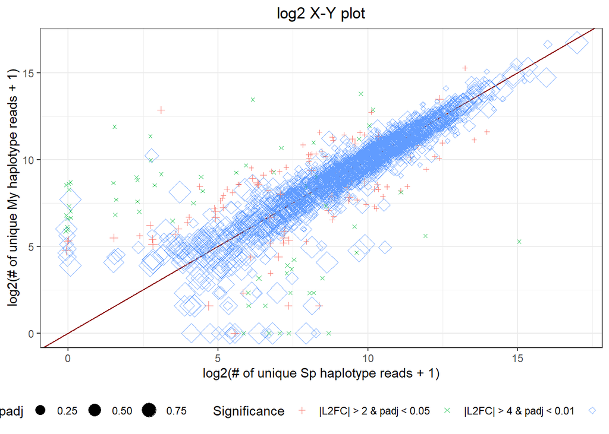

```r
ggplot(result.withGeneMap.asDF, aes(x=log2(unqC_Sp.total+1) , y= log2(unqC_My.total+1))) +
  labs(title = "log2 X-Y plot", x = "log2(# of unique Sp haplotype reads + 1)",
       y = "log2(# of unique My haplotype reads + 1)") +
  theme_bw() +
  theme(plot.title = element_text(hjust = 0.5), legend.position = "bottom") +
  geom_abline(slope =  1, intercept =  0, color = "darkred")+
  geom_point(aes(x=log2(unqC_Sp.total+1) , y= log2(unqC_My.total+1),
                 color = Significance, shape = Significance,
                 size = padj),
             position=position_jitter(w=0.1,h=0)) +
  scale_shape_manual(values=c(3, 4, 5)) #+
```

```r
  #scale_color_manual(name = "legend of significance")
```

#### Manhattan plot

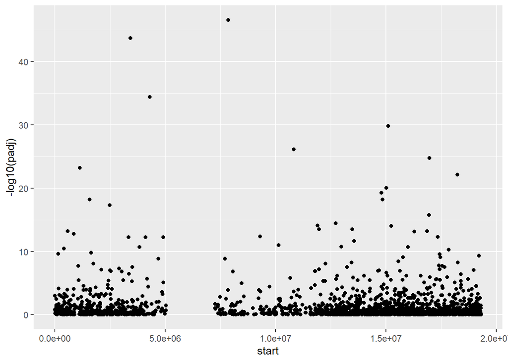

```r
ggplot(result.withGeneMap.asDF, aes(x = start, y = -log10(padj))) +
  geom_point(aes(x = start, y = -log10(padj)))
```

## Step F-05: Prepare data for boxplots

### F-05 I: Data for boxplot with top-20 genes by the lowes p-value

#### Additional manipulations with original data

```r
counts_2ms01e.joinTest <- counts_2ms01e %>%
  distinct(transcript_ID, .keep_all = TRUE)

counts_2ms02g.joinTest <- counts_2ms02g %>%
  distinct(transcript_ID, .keep_all = TRUE)

counts_2ms03g.joinTest <- counts_2ms03g %>%
  distinct(transcript_ID, .keep_all = TRUE)

counts_2ms04h.joinTest <- counts_2ms04h %>%
  distinct(transcript_ID, .keep_all = TRUE)
```

#### Get the data with all sample combined together (no filters applied)

```r
# Union samples verically
data_all <- rbind(counts_2ms01e.joinTest,
                  counts_2ms02g.joinTest,
                  counts_2ms03g.joinTest,
                  counts_2ms04h.joinTest)

# Get the variable which represent the QTL region
data_all <- data_all %>%
  mutate(unqC_Sum = unqC_My + unqC_Sp,
         qtl_pos = ifelse(start >= 12875963 & start <= 16344528, 1, 0))
```

#### Get the maximum allele expression (between both Sp and My) for each gene

This data will than be used for labelling genes.

```r
max_exp <- data_all %>%
  select(transcript_ID, gene_ID, unqC_My, unqC_Sp) %>%
  pivot_longer(c(unqC_My, unqC_Sp), names_to = "allele", values_to = "exp") %>%
  group_by(transcript_ID) %>%
  summarise(max_exp = max(exp))
```

#### Obtain top-20 genes by adjusted Wald-test p-value

```r
genes_20 <- result.withGeneMap.asDF %>%
  arrange(padj) %>%
  select(gene_ID, start, padj) %>%
  tibble::rownames_to_column("transcript_ID") %>%
  head(20) %>%
  left_join(max_exp, by = "transcript_ID") %>%
  mutate(max_log = log2(max_exp + 1) + 1,
         qtl_pos = ifelse(start >= 12875963 & start <= 16344528, 1, 0)) %>%
  arrange(start)
```

#### Prepare data for boxplot with top-20 genes

```r
data_bx_20 <- data_all %>%
  filter(gene_ID %in% genes_20$gene_ID) %>%
  select(transcript_ID, gene_ID, start, unqC_My, unqC_Sp) %>%
  pivot_longer(c(unqC_My, unqC_Sp), names_to = "allele", values_to = "exp") %>%
  mutate(log_exp = log2(exp + 1),
         qtl_pos = ifelse(start >= 12875963 & start <= 16344528, 1, 0))

genes_20_table <- data_all %>%
  filter(gene_ID %in% genes_20$gene_ID) %>%
  select(transcript_ID, unqC_My, unqC_Sp) %>%
  group_by(transcript_ID) %>%
  summarise(mean_My = mean(unqC_My),
            sd_My = sd(unqC_My),
            mean_Sp = mean(unqC_Sp),
            sd_Sp = sd(unqC_Sp)) %>%
  left_join(result.withGeneMap.asDF %>%
              tibble::rownames_to_column("transcript_ID") %>%
              select(transcript_ID, gene_ID, padj, start),
            by = "transcript_ID") %>%
  mutate(qtl_pos = ifelse(start >= 12875963 & start <= 16344528, 1, 0))
```

### F-05 II: Data for boxplot for Big Boxplot №1 (genes with p-value < 0.001)

In the part F-05 II and following parts F-05 III and F-05 IV we build “Big Boxplots”. These boxplots contain all the genes which follow a specific condidition of significance for difference in allele expression.

This critereas: * Big Boxplot №1 - all the genes which have Wald-test p-value < 0.001 * Big Boxplot №2 - all the genes which are in category: |L2FC| > 2 & padj < 0.05 * Big Boxplot №3 - all the genes which are in category: |L2FC| > 4 & padj < 0.01

#### Colors for coloring some separate boxplots

```r
colors <- c("#00A5E3", "#8DD7BF", "#FF96C5", "#FF5768", "#FFBF65", "#00B0BA")
```

#### Get the data for Big Boxplot №1 (genes with p-value < 0.001)

```r
genes_1 <- result.withGeneMap.asDF %>%
  filter(padj <= 0.001) %>%
  select(gene_ID, start, padj) %>%
  tibble::rownames_to_column("transcript_ID") %>%
  left_join(max_exp, by = "transcript_ID") %>%
  mutate(max_log = log2(max_exp + 1) + 1,
         qtl_pos = ifelse(start >= 12875963 & start <= 16344528, 1, 0)) %>%
  arrange(start)

data_bigbx1 <- data_all %>%
  filter(transcript_ID %in% genes_1$transcript_ID) %>%
  select(transcript_ID, gene_ID, start, unqC_My, unqC_Sp, unqC_Sum) %>%
  #pivot_longer(c(unqC_My, unqC_Sp), names_to = "allele", values_to = "exp") %>%
  mutate(
    #log_exp = log2(exp + 1),
    qtl_pos = ifelse(start >= 12875963 & start <= 16344528, 1, 0))
```

#### Get the data for boxplots with high maximum expression (withing both Sp and My)

Threshold in this case was chosen visually to keep only five boxplots filled with color for each of the plots.The same approach works for the other two big boxplots.

```r
gene_names1 <- data_bigbx1 %>%
  group_by(start, gene_ID) %>%
  dplyr::summarise(max = max(unqC_Sum)) %>%
  filter(max > 9000)
```

```r
high_boxplots1 <- data_bigbx1 %>%
  group_by(start, gene_ID) %>%
  filter(max(unqC_Sum) > 9000)
```

### F-05 III: Data for boxplot for Big Boxplot №2 (category = |L2FC| > 2 & padj < 0.05)

#### Prepare data for the boxplot

```r
genes_2 <- result.withGeneMap.asDF %>%
  filter(Significance == "|L2FC| > 2 & padj < 0.05") %>%
  select(gene_ID, start, padj) %>%
  tibble::rownames_to_column("transcript_ID") %>%
  left_join(max_exp, by = "transcript_ID") %>%
  mutate(max_log = log2(max_exp + 1) + 1,
         qtl_pos = ifelse(start >= 12875963 & start <= 16344528, 1, 0)) %>%
  arrange(start)

data_bigbx2 <- data_all %>%
  filter(transcript_ID %in% genes_2$transcript_ID) %>%
  select(transcript_ID, gene_ID, start, unqC_My, unqC_Sp, unqC_Sum) %>%
  #pivot_longer(c(unqC_My, unqC_Sp), names_to = "allele", values_to = "exp") %>%
  mutate(
    #log_exp = log2(exp + 1),
    qtl_pos = ifelse(start >= 12875963 & start <= 16344528, 1, 0))
```

#### Prepare data for the colored boxplots

```r
gene_names2 <- data_bigbx2 %>%
  group_by(start, gene_ID) %>%
  dplyr::summarise(max = max(unqC_Sum)) %>%
  filter(max > 3700)
```

```r
high_boxplots2 <- data_bigbx2 %>%
  group_by(start, gene_ID) %>%
  filter(max(unqC_Sum) > 3700)
```

### F-05 IV: Data for boxplot for Big Boxplot №3 (category = |L2FC| > 4 & padj < 0.01)

#### Prepare Data for the boxplot

```r
genes_3 <- result.withGeneMap.asDF %>%
  filter(Significance == "|L2FC| > 4 & padj < 0.01") %>%
  select(gene_ID, start, padj) %>%
  tibble::rownames_to_column("transcript_ID") %>%
  left_join(max_exp, by = "transcript_ID") %>%
  mutate(max_log = log2(max_exp + 1) + 1,
         qtl_pos = ifelse(start >= 12875963 & start <= 16344528, 1, 0)) %>%
  arrange(start)

data_bigbx3 <- data_all %>%
  filter(transcript_ID %in% genes_3$transcript_ID) %>%
  select(transcript_ID, gene_ID, start, unqC_My, unqC_Sp, unqC_Sum) %>%
  #pivot_longer(c(unqC_My, unqC_Sp), names_to = "allele", values_to = "exp") %>%
  mutate(
    #log_exp = log2(exp + 1),
    qtl_pos = ifelse(start >= 12875963 & start <= 16344528, 1, 0))
```

#### Prepare data for the colored boxplots

```r
gene_names3 <- data_bigbx3 %>%
  group_by(start, gene_ID) %>%
  dplyr::summarise(max = max(unqC_Sum)) %>%
  filter(max > 2100)
```

```r
high_boxplots3 <- data_bigbx3 %>%
  group_by(start, gene_ID) %>%
  filter(max(unqC_Sum) > 2100)
```

## Step F-06: Plot Boxplots

### F-06 I: Boxplot - top 20 genes

```r
grDevices::png(filename = "bx_20_v2.png",  width = 16.5, height = 10, units = 'cm', res = 400)

bx_20_v2 <- data_bx_20 %>%
  ggplot(mapping = aes(x = as.factor(start), y = log_exp, fill = as.factor(qtl_pos))) +
  geom_boxplot(alpha = 0.3) +
  geom_point(aes(color = allele),
             #position = position_jitter(),
             size = 1.3) +
  stat_summary(fun.y=mean, geom="point", shape=20, size=4, color="#FFA500", fill="#FFA500") +
  scale_color_manual("Haplotype",
                     values = c("#E63946", "#457b92"),
                     labels = c("My", "Sp")) +
  scale_fill_manual("QTL region", values = c("White", "#00A86B"),
                    labels = c("out", "in")) +
  scale_x_discrete(labels = genes_20$gene_ID) +
  labs(
    #title = "Top 20 genes with highest gene expression",
    y = "Log2(Expression + 1)",
    x = "Gene ID"
  ) +
  theme_bw() +
  theme(
    panel.grid.major = element_line(colour = 'grey85', size = 0.2),
    panel.grid.minor = element_line(colour = 'grey90', size = 0.1),
    axis.title.x = element_blank(),
    axis.title.y = element_text(size = 10),
    plot.title = element_blank(),
    axis.text.x = element_text(angle = 45, hjust=1),
    #legend.position = c(0.8,0.2), #You can adjust legend position here
    legend.background = element_rect(color = "black"),
    legend.title = element_text(size = 8),
    legend.text = element_text(size = 8)
  )
bx_20_v2

dev.off()
```

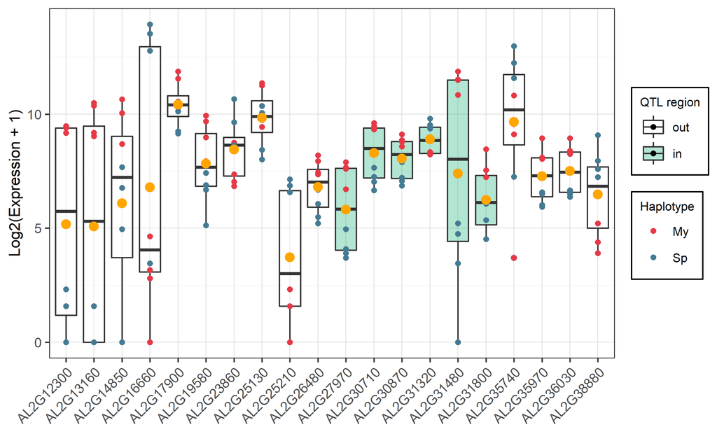

```r
knitr::include_graphics("bx_20_v2.png")
```

### F-06 II: Big Boxplot №1 (genes with p-value < 0.001)

```r
grDevices::png(filename = "bx_big1.png",  width = 16.5, height = 10, units = 'cm', res = 400)

bx_big1 <- data_bigbx1 %>%
  ggplot(mapping = aes(x = as.factor(start), y = unqC_Sum)) +
  geom_boxplot() +
  geom_boxplot(data = high_boxplots1, aes(x = as.factor(start), y = unqC_Sum, fill = gene_ID, color = gene_ID),
              show.legend = FALSE) +
  geom_point(data = data_bigbx1 %>% filter(qtl_pos == 1), aes(x = as.factor(start), y = 17500), shape = 15,
             size = 2.5, color = "#00A86B", fill = "#00A86B") +
  annotate("label", label = "QTL region", y = 18500, x = "14891953", size = 3) +
  #geom_rect(aes(xmin= as.factor("12875963"), xmax= as.factor("16344528"), ymin=0, ymax=Inf), alpha = 0.5) +
  #geom_segment(aes(x = "12875963", y = 0, xend = "12875963", yend = 17500)) +
  #scale_x_discrete(labels = levels(factor(data_bigbx1$gene_ID))) +
  scale_x_discrete(labels = levels(factor(data_bigbx1$gene_ID)),
                   guide = guide_axis(check.overlap = TRUE)
                   ) +
  scale_fill_manual(values = colors) +
  scale_color_manual(values = colors) +
  ggrepel::geom_label_repel(data = gene_names1, aes(x = as.factor(start), y = max, label = gene_ID, fill = gene_ID),
                            hjust = -0.2,
                            show.legend = FALSE) +
  labs(y = "Total Gene expression") +
  theme_bw() +
  theme(
    #panel.grid.major = element_line(colour = 'grey85', size = 0.2),
    #panel.grid.minor = element_line(colour = 'grey90', size = 0.1),
    axis.title.x = element_blank(),
    axis.title.y = element_text(size = 10),
    #axis.title.y = element_blank(),
    plot.title = element_text(size = 10),
    axis.text.x = element_text(angle = 45, hjust=1),
    #legend.position = c(0.8,0.2), #You can adjust legend position here
    legend.background = element_rect(color = "black")
  )

bx_big1

dev.off()
```

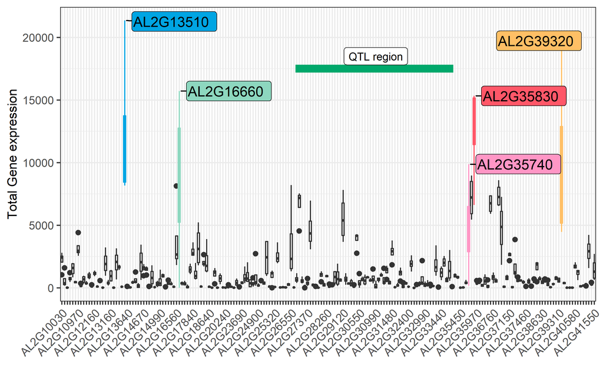

```r
knitr::include_graphics("bx_big1.png")
```

### F-06 III: Big Boxplot №2 (category = |L2FC| > 2 & padj < 0.05)

```r
grDevices::png(filename = "bx_big2.png",  width = 16.5, height = 10, units = 'cm', res = 400)

bx_big2 <- data_bigbx2 %>%
  ggplot(mapping = aes(x = as.factor(start), y = unqC_Sum)) +
  geom_boxplot() +
  geom_boxplot(data = high_boxplots2, aes(x = as.factor(start), y = unqC_Sum, fill = gene_ID, color = gene_ID),
               show.legend = FALSE) +
  geom_point(data = data_bigbx2 %>% filter(qtl_pos == 1), aes(x = as.factor(start), y = 17500), shape = 15,
             size = 2.5, color = "#00A86B", fill = "#00A86B") +
  annotate("label", label = "QTL region", y = 18500, x = "14795486", size = 3) +
  #geom_rect(aes(xmin= as.factor("12875963"), xmax= as.factor("16344528"), ymin=0, ymax=Inf), alpha = 0.5) +
  #geom_segment(aes(x = "12875963", y = 0, xend = "12875963", yend = 17500)) +
  #scale_x_discrete(labels = levels(factor(data_bigbx1$gene_ID))) +
  scale_x_discrete(labels = levels(factor(data_bigbx2$gene_ID)),
                   guide = guide_axis(check.overlap = TRUE)
  ) +
  scale_fill_manual(values = colors) +
  scale_color_manual(values = colors) +
  ggrepel::geom_label_repel(data = gene_names2, aes(x = as.factor(start), y = max, label = gene_ID, fill = gene_ID),
                            hjust = -0.2,
                            show.legend = FALSE) +
  labs(y = "Total Gene expression") +
  theme_bw() +
  theme(
    #panel.grid.major = element_line(colour = 'grey85', size = 0.2),
    #panel.grid.minor = element_line(colour = 'grey90', size = 0.1),
    axis.title.x = element_blank(),
    axis.title.y = element_text(size = 10),
    #axis.title.y = element_blank(),
    plot.title = element_text(size = 10),
    axis.text.x = element_text(angle = 45, hjust=1),
    #legend.position = c(0.8,0.2), #You can adjust legend position here
    legend.background = element_rect(color = "black")
  )

bx_big2

dev.off()
```

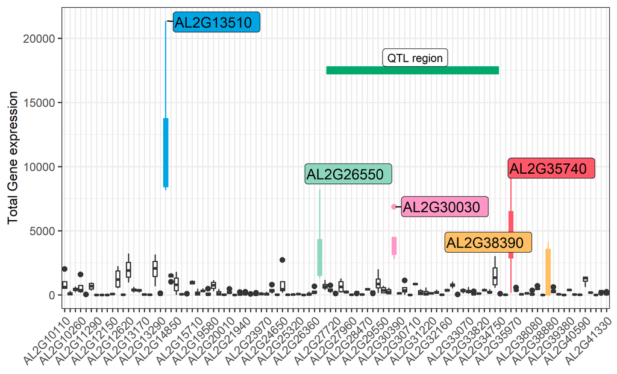

```r
knitr::include_graphics("bx_big2.png")
```